# Project3_DATA607

Mahmud Hasan Al Raji &Ivan Tikhonov & Joyce Aldrich & Ariana Nolan

2022-10-22

#install new package #GCOOKBOOK

```r
#install.packages("gcookbook")
```

```r
library(readr)
library(dplyr)
```

```r
library(tidyr)
library(stringr)
library(ggplot2)
library(magrittr)
library(gcookbook)
library(forcats)
```

# Getting the data

```r
skills_data<-read.csv("https://raw.githubusercontent.com/Raji030/data_science_skills/main/ds_general_skills_revised.csv", sep=",",header = TRUE)

skills_data
```

```
##                                                                                               Keyword
## 1                                                                                    machine learning
## 2                                                                                            analysis
## 3                                                                                          statistics
## 4                                                                                    computer science
## 5                                                                                       communication
## 6                                                                                         mathematics
## 7                                                                                       visualization
## 8                                                                                        AI composite
## 9                                                                                       deep learning
## 10                                                                                      NLP composite
## 11                                                                               software development
## 12                                                                                    neural networks
## 13                                                                                   data engineering
## 14                                                                                 project management
```

[output cut: 47 more lines]

```r
glimpse(skills_data)
```

```
## Rows: 30
## Columns: 5
## $ Keyword     <chr> "machine learning", "analysis", "statistics", "computer sc…
## $ LinkedIn    <chr> "5,701", "5,168", "4,893", "4,517", "3,404", "2,605", "1,8…
## $ Indeed      <chr> "3,439", "3,500", "2,992", "2,739", "2,344", "1,961", "1,4…
## $ SimplyHired <chr> "2,561", "2,668", "2,308", "2,093", "1,791", "1,497", "1,1…
## $ Monster     <chr> "2,340", "3,306", "2,399", "1,900", "2,053", "1,815", "1,2…
```

# Data Cleaning:

```r
#Removing empty rows

data_1<- skills_data[!apply(skills_data == "", 1, all),]
data_1
```

```
##                                                                                               Keyword
## 1                                                                                    machine learning
## 2                                                                                            analysis
## 3                                                                                          statistics
## 4                                                                                    computer science
## 5                                                                                       communication
## 6                                                                                         mathematics
## 7                                                                                       visualization
## 8                                                                                        AI composite
## 9                                                                                       deep learning
## 10                                                                                      NLP composite
## 11                                                                               software development
## 12                                                                                    neural networks
## 13                                                                                   data engineering
## 14                                                                                 project management
```

[output cut: 39 more lines]

```r
#Removing rows that have data redundancy

data_2<-data_1[-(17:30),]
data_2
```

```
##                 Keyword LinkedIn Indeed SimplyHired Monster
## 1      machine learning    5,701  3,439       2,561   2,340
## 2              analysis    5,168  3,500       2,668   3,306
## 3            statistics    4,893  2,992       2,308   2,399
## 4      computer science    4,517  2,739       2,093   1,900
## 5         communication    3,404  2,344       1,791   2,053
## 6           mathematics    2,605  1,961       1,497   1,815
## 7         visualization    1,879  1,413       1,153   1,207
## 8          AI composite    1,568  1,125         811     687
## 9         deep learning    1,310    979         675     606
## 10        NLP composite    1,212    910         660     582
## 11 software development      732    627         481     784
## 12      neural networks      671    485         421     305
## 13     data engineering      514    339         276     200
## 14   project management      476    397         330     348
## 15 software engineering      413    295         250     512
## 17                Total   35,063 23,545      17,975  19,044
```

```r
# Replacing skill names that have abbreviated parts in Keyword column

data_2$Keyword[data_2$Keyword == "AI composite"] <- "artificial intelligence"
data_2$Keyword[data_2$Keyword == "NLP composite"] <- "natural language processing"
data_2
```

```
##                        Keyword LinkedIn Indeed SimplyHired Monster
## 1             machine learning    5,701  3,439       2,561   2,340
## 2                     analysis    5,168  3,500       2,668   3,306
## 3                   statistics    4,893  2,992       2,308   2,399
## 4             computer science    4,517  2,739       2,093   1,900
## 5                communication    3,404  2,344       1,791   2,053
## 6                  mathematics    2,605  1,961       1,497   1,815
## 7                visualization    1,879  1,413       1,153   1,207
## 8      artificial intelligence    1,568  1,125         811     687
## 9                deep learning    1,310    979         675     606
## 10 natural language processing    1,212    910         660     582
## 11        software development      732    627         481     784
## 12             neural networks      671    485         421     305
## 13            data engineering      514    339         276     200
## 14          project management      476    397         330     348
## 15        software engineering      413    295         250     512
## 17                       Total   35,063 23,545      17,975  19,044
```

# Data Transform- Convert the data from char to numeric / add another sum for each skill / remove total row

```r
data_2$LinkedIn = as.numeric(gsub("[^[:digit:]]","",data_2$LinkedIn))
data_2$Indeed = as.numeric(gsub("[^[:digit:]]","",data_2$Indeed))
data_2$SimplyHired = as.numeric(gsub("[^[:digit:]]","",data_2$SimplyHired))
data_2$Monster = as.numeric(gsub("[^[:digit:]]","",data_2$Monster))

data_3 <- data_2 %>%
  mutate(total_count = rowSums(across(where(is.numeric))))

data_3 <- data_3[-c(16),]

data_3<- data_3 %>%
 rename(Data_Skills = Keyword)
```

# select top 5 & bottom 5 skills

```r
library(dbplyr)
Top_5 <- data_3 %>%
  #select(Data_Skills,total_count) %>%
  slice_max(total_count, n=5)

Bottom_5 <-data_3 %>%
  #select(Data_Skills,total_count) %>%
  slice_min(total_count,n=5)

Top_Bottom <-rbind(Top_5,Bottom_5)
```

# Overall Top 5 & Bottom 5- Data Scientist Skills

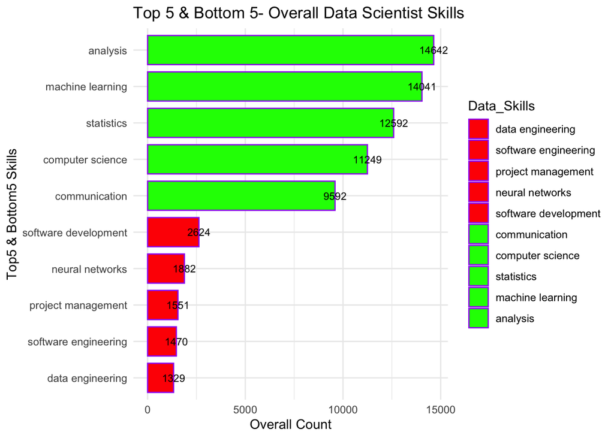

```r
Top_Bottom_Overall <- Top_Bottom %>%
mutate(Data_Skills = fct_reorder(Data_Skills, total_count)) %>%
select (Data_Skills,total_count) %>%
ggplot( aes(x=total_count,y=Data_Skills, fill=Data_Skills))+
  geom_bar(stat='identity',width = 0.8,color='purple') +
  scale_fill_manual(values = c("red","red","red","red","red","green","green","green","green","green")) +
  geom_text(aes(label=total_count),size =3)+
  theme_minimal()+
    ggtitle("Top 5 & Bottom 5- Overall Data Scientist Skills ") +
      labs(y="Top5 & Bottom5 Skills", x="Overall Count")

Top_Bottom_Overall
```

# LinkedIn Top 5 & Bottom 5 Data Scientist Skills

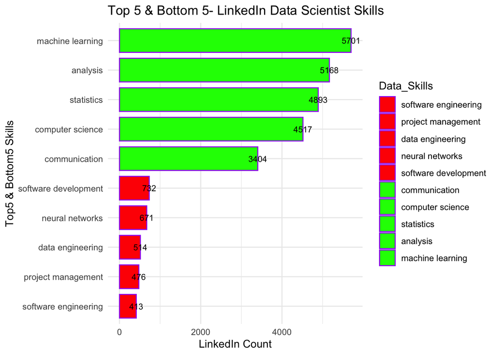

```r
Top_Bottom_LinkedIn <- Top_Bottom %>%
mutate(Data_Skills = fct_reorder(Data_Skills, LinkedIn)) %>%
select (Data_Skills,LinkedIn) %>%
ggplot( aes(x=LinkedIn,y=Data_Skills, fill=Data_Skills))+
  geom_bar(stat='identity',width = 0.8,color='purple') +
  scale_fill_manual(values = c("red","red","red","red","red","green","green","green","green","green")) +
  geom_text(aes(label=LinkedIn),size =3)+
  theme_minimal()+
    ggtitle("Top 5 & Bottom 5- LinkedIn Data Scientist Skills ") +
      labs(y="Top5 & Bottom5 Skills", x="LinkedIn Count")

Top_Bottom_LinkedIn
```

# Indeed Top 5 & Bottom 5 Data Scientist Skills

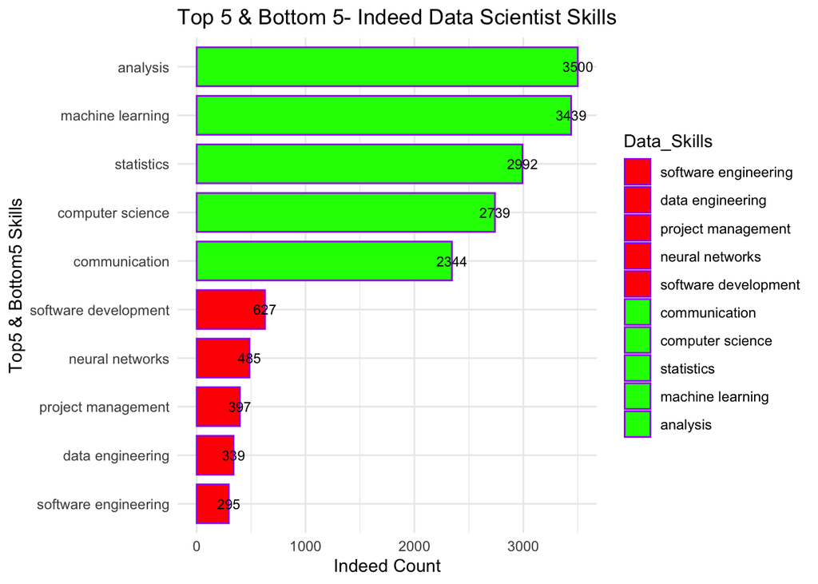

```r
Top_Bottom_Indeed <- Top_Bottom %>%
mutate(Data_Skills = fct_reorder(Data_Skills, Indeed )) %>%
select (Data_Skills,Indeed) %>%
ggplot( aes(x=Indeed,y=Data_Skills, fill=Data_Skills))+
  geom_bar(stat='identity',width = 0.8,color='purple') +
  scale_fill_manual(values = c("red","red","red","red","red","green","green","green","green","green")) +
  geom_text(aes(label=Indeed),size =3)+
  theme_minimal()+
    ggtitle("Top 5 & Bottom 5- Indeed Data Scientist Skills") +
      labs(y="Top5 & Bottom5 Skills", x="Indeed Count")

Top_Bottom_Indeed
```

# SimplyHired Top 5 & Bottom 5 Data Scientist Skills

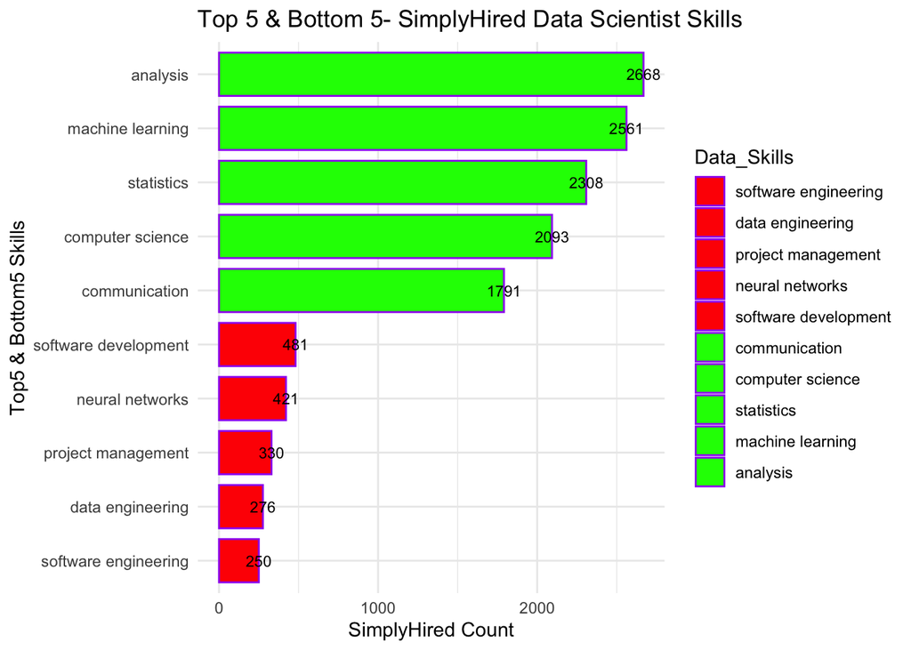

```r
Top_Bottom_SimplyHired <- Top_Bottom %>%
mutate(Data_Skills = fct_reorder(Data_Skills, SimplyHired)) %>%
select (Data_Skills,SimplyHired) %>%
ggplot( aes(x=SimplyHired,y=Data_Skills, fill=Data_Skills))+
  geom_bar(stat='identity',width = 0.8,color='purple') +
  scale_fill_manual(values = c("red","red","red","red","red","green","green","green","green","green")) +
  geom_text(aes(label=SimplyHired),size =3)+
  theme_minimal()+
    ggtitle("Top 5 & Bottom 5- SimplyHired Data Scientist Skills") +
      labs(y="Top5 & Bottom5 Skills", x="SimplyHired Count")

Top_Bottom_SimplyHired
```

# Monster Top 5 & Bottom 5 Data Scientist Skills

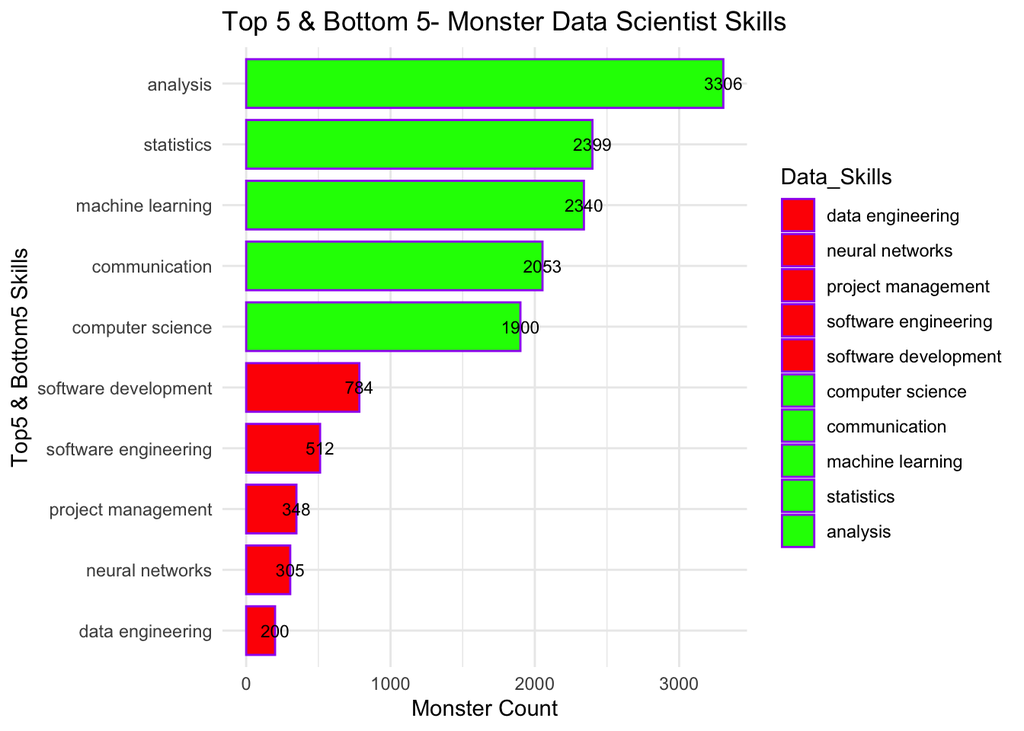

```r
Top_Bottom_Monster <- Top_Bottom %>%
mutate(Data_Skills = fct_reorder(Data_Skills, Monster)) %>%
select (Data_Skills,Monster) %>%
ggplot( aes(x=Monster,y=Data_Skills, fill=Data_Skills))+
  geom_bar(stat='identity',width = 0.8,color='purple') +
  scale_fill_manual(values = c("red","red","red","red","red","green","green","green","green","green")) +
  geom_text(aes(label=Monster),size =3)+
  theme_minimal()+
    ggtitle("Top 5 & Bottom 5- Monster Data Scientist Skills") +
      labs(y="Top5 & Bottom5 Skills", x="Monster Count")

Top_Bottom_Monster
```

# Analysis

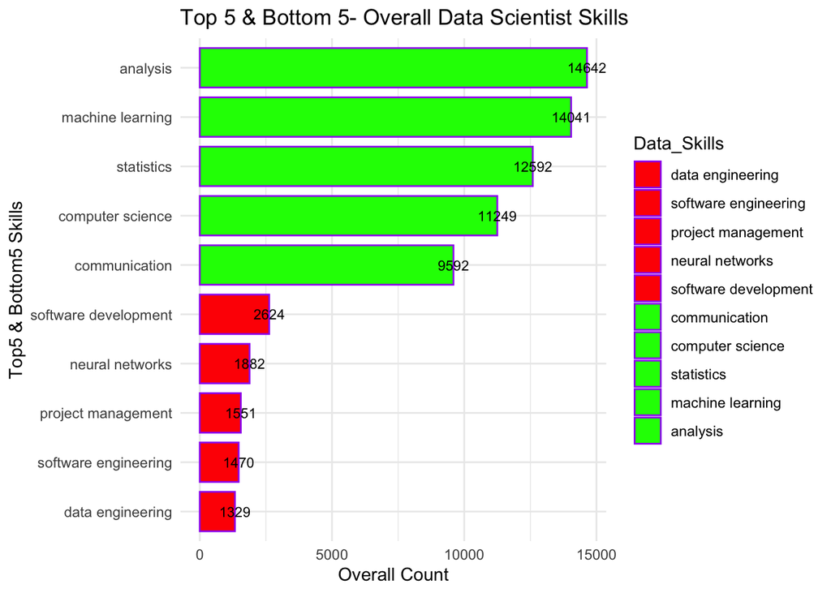

```r
Top_Bottom_Overall
```

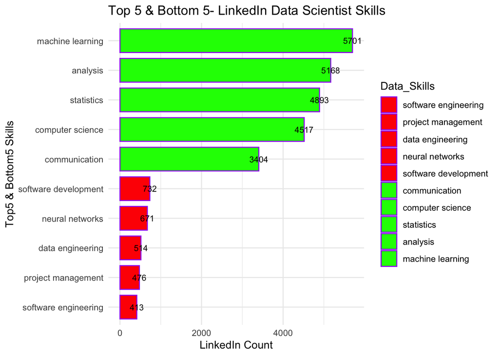

```r
Top_Bottom_LinkedIn
```

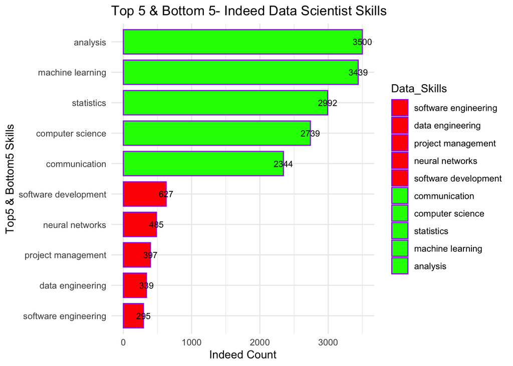

```r
Top_Bottom_Indeed
```

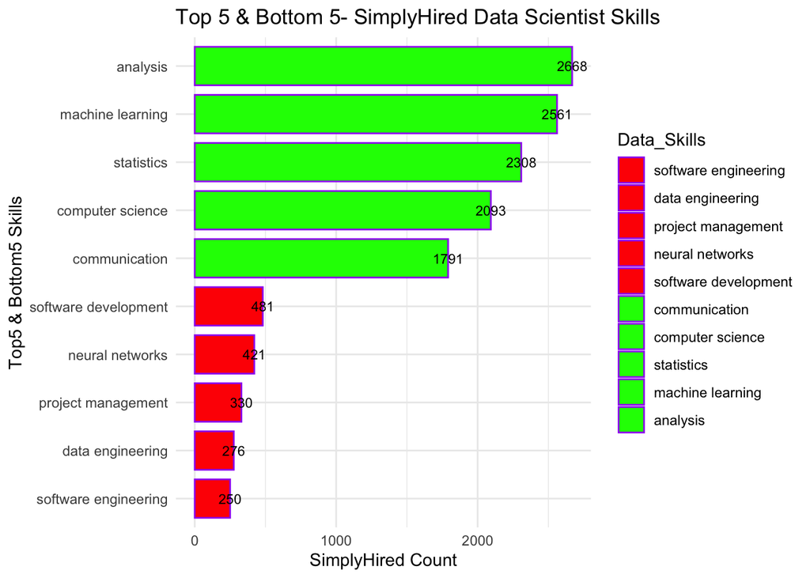

```r
Top_Bottom_SimplyHired
```

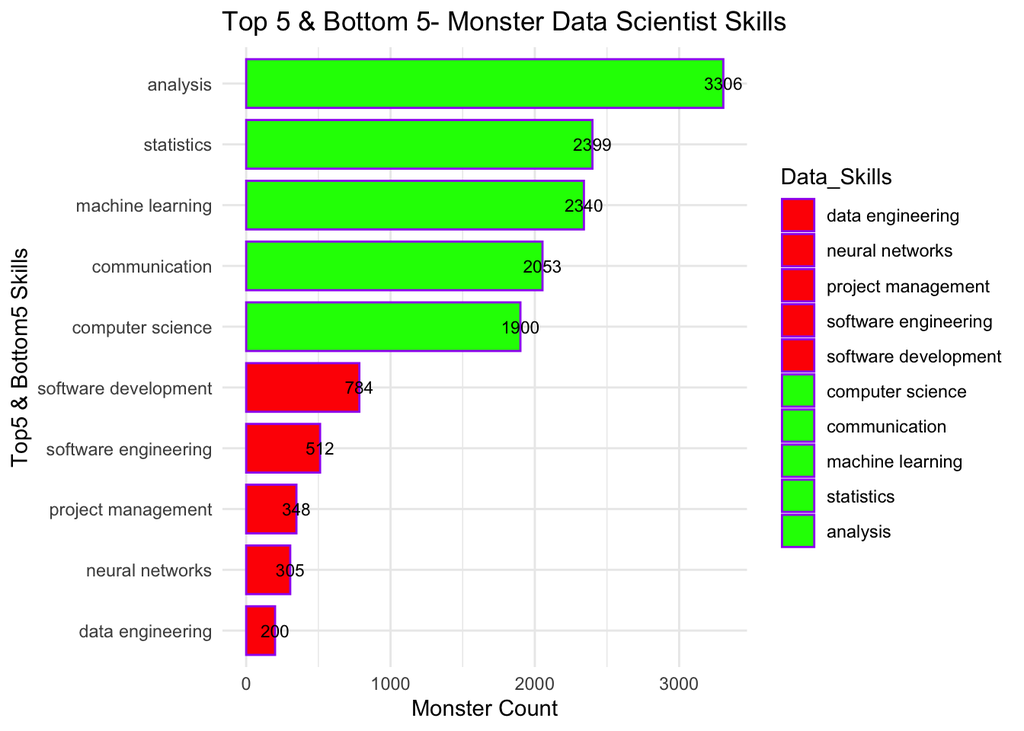

```r
Top_Bottom_Monster
```

Analysis: 1. LinkedIn- Machine Learning skill is top one (1) and Software Engineering Skill is bottom one (1) compare to the overall skills.(total count almost twice size than SimplyHired) 2. Indeed- Top five skills are overlapping to over skills order but bottom two is data engineering and than software engineering skill which opposite of overall skills’ order. Top1 skill and Top2 skill’s count are close to each other less than 100 count. 3. SimplyHired - Same as Indeed. 4. Monster- Top one skill is 37% increasing from the top two skill and Machine Learning skill dropped to Top three(3) and communication skill’s order is higher than overall skills and others 3 job websites. Software engineering skill is bottom one (1) or bottom two (2) for overall skills or other job websites’ skills but the order is the second of bottom 5 for Monster.